# MGT__256_Project_Predictive Models

Part 1: Repeating Data Cleaning Steps

```r
library(tidyverse)
```

```r
airbnb_palette <- c("#FF5A5F", "#00A699", "#767676", "#484848", "#FFB400")

main_uncleaned_data <- read_csv("airbnb1.csv")
# Calculate the percentage of missing data for each column
missing_data <- main_uncleaned_data %>%
  summarise(across(everything(), ~ mean(is.na(.)) * 100)) %>%
  pivot_longer(cols = everything(), names_to = "Variable", values_to = "Missing_Percentage")
```

```r
which(is.na(main_uncleaned_data))
```

```
  [1]   388   420   540   844   967  1123  1399  1874  1894  2006  2132  2221  2356  2657  2990  3121  3247  3746  3920  3945  4052  4121  4598  4669  4956  5227  5268
 [28]  5587  5935  5950  6122  6232  6483  6546  6617  7090  7245  7375  7416  7824  8387  8642  8662  9032  9063  9157  9158  9201  9471  9562 10128 10181 10347 10961
 [55] 11001 11193 11278 11331 11575 12046 12321 12410 12567 12727 12839 13294 13502 13607 13921 14007 14331 14338 14441 14609 15039 15219 15595 15977 16001 16095 16291
 [82] 16495 16640 17123 17126 17297 17333 17455 18134 18142 18242 18473 19057 19060 19129 19456 19600 19630 19840 20155 20564 20658 20785 21059 21170 21478 21515 21551
[109] 21746 21862 22474 22599 22819 23092 23109 23548 23934 24002 24087 24147 24231 24375 24628 24656 24692 25018
```

```r
col_missing <- colSums(is.na(main_uncleaned_data))

col_missing
```

```
         property_type              room_type           accommodates              bathrooms               bedrooms                   beds        amenities_count
                     5                      5                      5                      5                      5                      5                      5
        minimum_nights         maximum_nights      number_of_reviews   review_scores_rating      reviews_per_month        availability_30        availability_60
                     5                      5                      5                      5                      5                      5                      5
       availability_90       availability_365       instant_bookable host_identity_verified             host_since    cancellation_policy               latitude
                     5                      5                      5                      5                      5                      5                      5
             longitude        guests_included           extra_people                  price
                     5                      5                      6                      5
```

```r
dropped_na <- main_uncleaned_data %>% drop_na()

which(is.na(dropped_na)) # just checking if the cleaning worked or not
```

```
integer(0)
```

```r
Q1 <- quantile(dropped_na$bedrooms, 0.25, na.rm = TRUE)
Q3 <- quantile(dropped_na$bedrooms, 0.75, na.rm = TRUE)
IQR <- Q3 - Q1

cleaned_airbnb_data <- dropped_na %>%
  filter(bedrooms >= (Q1 - 1.5 * IQR) & bedrooms <= (Q3 + 1.5 * IQR))

glimpse(cleaned_airbnb_data)
```

```
Rows: 886
Columns: 25
$ property_type          <chr> "Apartment", "Townhouse", "Apartment", "Apartment", "House", "Loft", "House", "House", "Apartment", "Loft", "Apartment", "Bed & Breakfast"…
$ room_type              <chr> "Entire home/apt", "Entire home/apt", "Entire home/apt", "Entire home/apt", "Entire home/apt", "Private room", "Private room", "Entire hom…
$ accommodates           <dbl> 6, 2, 2, 4, 8, 5, 3, 2, 5, 3, 5, 9, 4, 4, 4, 1, 1, 2, 8, 8, 2, 5, 3, 3, 4, 3, 3, 2, 5, 2, 7, 4, 7, 2, 9, 1, 2, 9, 1, 4, 7, 2, 7, 1, 8, 1, …
$ bathrooms              <dbl> 1, 4, 1, 4, 1, 3, 1, 3, 4, 2, 4, 1, 4, 4, 2, 2, 2, 1, 3, 3, 4, 1, 1, 4, 4, 1, 1, 2, 1, 2, 4, 4, 2, 4, 3, 1, 3, 1, 2, 4, 4, 3, 4, 1, 3, 1, …
$ bedrooms               <dbl> 3, 1, 4, 2, 2, 2, 1, 5, 2, 4, 3, 3, 1, 5, 4, 4, 5, 5, 5, 3, 3, 5, 4, 1, 2, 2, 2, 2, 3, 3, 1, 5, 2, 4, 4, 2, 1, 4, 1, 3, 4, 1, 3, 5, 3, 5, …
$ beds                   <dbl> 2, 1, 4, 1, 1, 1, 1, 5, 3, 5, 4, 3, 1, 6, 5, 5, 5, 6, 4, 3, 2, 6, 5, 1, 1, 2, 2, 2, 4, 2, 1, 5, 2, 3, 3, 2, 1, 3, 1, 4, 5, 2, 2, 5, 4, 4, …
$ amenities_count        <dbl> 41, 31, 8, 49, 23, 40, 20, 14, 25, 49, 48, 39, 37, 35, 19, 27, 11, 16, 28, 48, 8, 30, 22, 24, 39, 33, 12, 35, 35, 44, 10, 9, 35, 43, 5, 19…
$ minimum_nights         <dbl> 2, 2, 1, 9, 5, 3, 8, 1, 7, 8, 2, 3, 6, 6, 4, 5, 8, 8, 3, 6, 7, 3, 2, 8, 6, 9, 3, 6, 8, 8, 7, 8, 8, 6, 1, 6, 4, 6, 1, 5, 8, 5, 4, 5, 5, 8, …
$ maximum_nights         <dbl> 503, 83, 256, 714, 55, 869, 486, 817, 697, 1101, 328, 984, 312, 1051, 411, 789, 398, 1111, 184, 379, 1004, 129, 581, 697, 642, 743, 510, 9…
$ number_of_reviews      <dbl> 10, 7, 9, 8, 16, 9, 10, 8, 8, 7, 8, 7, 10, 11, 12, 8, 3, 12, 9, 10, 15, 16, 14, 10, 11, 8, 9, 13, 11, 14, 9, 6, 3, 6, 5, 9, 18, 10, 10, 7,…
$ review_scores_rating   <dbl> 2, 1, 2, 5, 2, 4, 1, 3, 5, 1, 2, 4, 3, 1, 2, 3, 3, 1, 3, 1, 1, 4, 3, 5, 3, 5, 2, 1, 1, 2, 4, 4, 1, 4, 3, 4, 4, 4, 4, 2, 4, 1, 4, 3, 2, 2, …
$ reviews_per_month      <dbl> 2.8, 4.9, 4.1, 2.6, 3.8, 1.6, 5.0, 3.7, 4.1, 4.9, 3.0, 4.7, 3.4, 1.2, 3.7, 3.6, 2.2, 3.3, 0.6, 2.8, 4.1, 0.7, 0.8, 3.9, 1.3, 4.3, 3.4, 1.9…
$ availability_30        <dbl> 23, 19, 2, 8, 5, 0, 24, 9, 28, 2, 28, 5, 26, 28, 26, 29, 2, 23, 11, 3, 28, 16, 26, 22, 16, 18, 25, 30, 12, 22, 8, 26, 27, 20, 10, 8, 21, 3…
$ availability_60        <dbl> 56, 57, 37, 7, 14, 22, 45, 58, 26, 37, 19, 49, 9, 40, 51, 2, 53, 54, 27, 49, 52, 23, 55, 4, 9, 47, 16, 13, 57, 7, 55, 41, 51, 5, 18, 7, 6,…
$ availability_90        <dbl> 41, 87, 65, 34, 57, 47, 83, 77, 78, 12, 21, 8, 71, 23, 50, 9, 89, 0, 70, 44, 28, 26, 5, 86, 82, 26, 56, 36, 66, 72, 88, 5, 55, 75, 7, 82, …
$ availability_365       <dbl> 18, 196, 278, 263, 30, 44, 185, 230, 336, 18, 221, 52, 72, 233, 121, 62, 242, 217, 80, 201, 352, 332, 98, 73, 343, 210, 44, 243, 286, 108,…
$ instant_bookable       <dbl> 0, 0, 0, 1, 1, 1, 0, 0, 1, 0, 1, 0, 0, 0, 0, 1, 0, 0, 1, 0, 1, 1, 0, 0, 0, 0, 1, 0, 1, 0, 1, 0, 0, 1, 1, 1, 1, 1, 1, 0, 1, 0, 0, 1, 1, 1, …
$ host_identity_verified <dbl> 1, 1, 0, 1, 1, 1, 1, 1, 1, 1, 0, 1, 1, 1, 1, 1, 0, 1, 1, 1, 1, 1, 1, 1, 0, 1, 1, 1, 1, 0, 1, 1, 1, 1, 1, 1, 0, 1, 1, 0, 1, 0, 1, 1, 0, 0, …
$ host_since             <dbl> 1652, 1126, 1728, 3264, 902, 2773, 771, 424, 1952, 552, 1318, 1507, 1014, 2518, 3486, 3567, 1618, 2103, 2478, 2619, 450, 757, 1686, 3412, …
$ cancellation_policy    <chr> "flexible", "flexible", "strict", "strict_14_with_grace_period", "strict_14_with_grace_period", "flexible", "strict_14_with_grace_period",…
$ latitude               <dbl> 40.72955, 40.62440, 40.59282, 40.71197, 40.85087, 40.85365, 40.88695, 40.62214, 40.87585, 40.58263, 40.53245, 40.67763, 40.87789, 40.53903…
$ longitude              <dbl> -73.93356, -73.88089, -73.74172, -73.91624, -73.72905, -73.86373, -73.76245, -73.84639, -73.86990, -73.82194, -73.97853, -73.73979, -73.74…
$ guests_included        <dbl> 4, 4, 4, 1, 4, 1, 2, 4, 4, 2, 1, 2, 2, 4, 1, 4, 4, 1, 1, 4, 3, 4, 3, 3, 1, 2, 2, 3, 1, 1, 1, 4, 3, 1, 4, 1, 4, 1, 1, 2, 2, 3, 4, 3, 3, 1, …
$ extra_people           <dbl> 3, 41, 5, 6, 6, 31, 19, 34, 29, 9, 47, 0, 21, 7, 29, 42, 17, 24, 10, 3, 0, 4, 3, 49, 6, 21, 23, 43, 15, 31, 2, 35, 5, 45, 28, 27, 13, 34, …
$ price                  <dbl> 327, 335, 213, 399, 301, 319, 272, 344, 307, 341, 397, 321, 408, 504, 285, 346, 293, 322, 342, 460, 336, 330, 361, 336, 366, 235, 195, 349…
```

```r
numeric_vars <- c("bathrooms", "bedrooms", "beds", "amenities_count", "minimum_nights", "maximum_nights", "number_of_reviews", "review_scores_rating", "price","availability_30","availability_60","availability_90","availability_365")

categorical_vars <- c("property_type", "room_type", "cancellation_policy", "instant_bookable")
```

```r
for (var in categorical_vars) {
  # Create dummy variables using model.matrix() and remove intercept column
  dummy_vars <- model.matrix(as.formula(paste("~", var, "- 1")), data = cleaned_airbnb_data)

  # Append dummy variables to the original dataset
  cleaned_airbnb_data <- cbind(cleaned_airbnb_data, dummy_vars)
}

# Drop columns by selecting the ones not in categorical_vars
cleaned_airbnb_data <- cleaned_airbnb_data[, !(names(cleaned_airbnb_data) %in% categorical_vars)]

#
# # View the updated dataset to verify the dummy variables
glimpse(cleaned_airbnb_data)
```

```
Rows: 886
Columns: 36
$ accommodates                                   <dbl> 6, 2, 2, 4, 8, 5, 3, 2, 5, 3, 5, 9, 4, 4, 4, 1, 1, 2, 8, 8, 2, 5, 3, 3, 4, 3, 3, 2, 5, 2, 7, 4, 7, 2, 9, 1, 2, 9, …
$ bathrooms                                      <dbl> 1, 4, 1, 4, 1, 3, 1, 3, 4, 2, 4, 1, 4, 4, 2, 2, 2, 1, 3, 3, 4, 1, 1, 4, 4, 1, 1, 2, 1, 2, 4, 4, 2, 4, 3, 1, 3, 1, …
$ bedrooms                                       <dbl> 3, 1, 4, 2, 2, 2, 1, 5, 2, 4, 3, 3, 1, 5, 4, 4, 5, 5, 5, 3, 3, 5, 4, 1, 2, 2, 2, 2, 3, 3, 1, 5, 2, 4, 4, 2, 1, 4, …
$ beds                                           <dbl> 2, 1, 4, 1, 1, 1, 1, 5, 3, 5, 4, 3, 1, 6, 5, 5, 5, 6, 4, 3, 2, 6, 5, 1, 1, 2, 2, 2, 4, 2, 1, 5, 2, 3, 3, 2, 1, 3, …
$ amenities_count                                <dbl> 41, 31, 8, 49, 23, 40, 20, 14, 25, 49, 48, 39, 37, 35, 19, 27, 11, 16, 28, 48, 8, 30, 22, 24, 39, 33, 12, 35, 35, …
$ minimum_nights                                 <dbl> 2, 2, 1, 9, 5, 3, 8, 1, 7, 8, 2, 3, 6, 6, 4, 5, 8, 8, 3, 6, 7, 3, 2, 8, 6, 9, 3, 6, 8, 8, 7, 8, 8, 6, 1, 6, 4, 6, …
$ maximum_nights                                 <dbl> 503, 83, 256, 714, 55, 869, 486, 817, 697, 1101, 328, 984, 312, 1051, 411, 789, 398, 1111, 184, 379, 1004, 129, 58…
$ number_of_reviews                              <dbl> 10, 7, 9, 8, 16, 9, 10, 8, 8, 7, 8, 7, 10, 11, 12, 8, 3, 12, 9, 10, 15, 16, 14, 10, 11, 8, 9, 13, 11, 14, 9, 6, 3,…
$ review_scores_rating                           <dbl> 2, 1, 2, 5, 2, 4, 1, 3, 5, 1, 2, 4, 3, 1, 2, 3, 3, 1, 3, 1, 1, 4, 3, 5, 3, 5, 2, 1, 1, 2, 4, 4, 1, 4, 3, 4, 4, 4, …
$ reviews_per_month                              <dbl> 2.8, 4.9, 4.1, 2.6, 3.8, 1.6, 5.0, 3.7, 4.1, 4.9, 3.0, 4.7, 3.4, 1.2, 3.7, 3.6, 2.2, 3.3, 0.6, 2.8, 4.1, 0.7, 0.8,…
$ availability_30                                <dbl> 23, 19, 2, 8, 5, 0, 24, 9, 28, 2, 28, 5, 26, 28, 26, 29, 2, 23, 11, 3, 28, 16, 26, 22, 16, 18, 25, 30, 12, 22, 8, …
$ availability_60                                <dbl> 56, 57, 37, 7, 14, 22, 45, 58, 26, 37, 19, 49, 9, 40, 51, 2, 53, 54, 27, 49, 52, 23, 55, 4, 9, 47, 16, 13, 57, 7, …
$ availability_90                                <dbl> 41, 87, 65, 34, 57, 47, 83, 77, 78, 12, 21, 8, 71, 23, 50, 9, 89, 0, 70, 44, 28, 26, 5, 86, 82, 26, 56, 36, 66, 72…
```

[output cut: 23 more lines]

Step 1: Splitting data into training and validation

```r
#splitting data
library(caret)
library(MASS)
set.seed(2)
trainIndex <- createDataPartition(cleaned_airbnb_data$price, p = 0.6, list = FALSE)
train <- cleaned_airbnb_data[trainIndex, ]
test <- cleaned_airbnb_data[-trainIndex, ]

colnames(train)[colnames(train) == "room_typeEntire home/apt"] <- "room_typeEntire_home/apt"
colnames(train)[colnames(train) == "property_typeBed & Breakfast"] <- "property_typeBed_&_Breakfast"

colnames(test)[colnames(test) == "room_typeEntire home/apt"] <- "room_typeEntire_home/apt"
colnames(test)[colnames(test) == "property_typeBed & Breakfast"] <- "property_typeBed_&_Breakfast"
```

Spet 2: Model Selection Full model with all variables to find out significant and insignificant variables

```r
#full model will all variables

full_model <- lm(price ~ ., data = train)
summary(full_model)
```

```
Call:
lm(formula = price ~ ., data = train)

Residuals:
    Min      1Q  Median      3Q     Max
-641.37  -32.20    0.29   35.81  133.25

Coefficients: (3 not defined because of singularities)
                                                 Estimate Std. Error t value Pr(>|t|)
(Intercept)                                    -1.186e+03  2.736e+03  -0.433 0.664954
accommodates                                    8.807e+00  1.124e+00   7.835 2.83e-14 ***
bathrooms                                       1.848e+01  2.536e+00   7.288 1.23e-12 ***
bedrooms                                        1.194e+01  4.077e+00   2.929 0.003555 **
beds                                            2.254e+00  3.774e+00   0.597 0.550553
amenities_count                                 2.080e+00  2.273e-01   9.149  < 2e-16 ***
minimum_nights                                  7.702e-01  1.129e+00   0.682 0.495306
maximum_nights                                  1.156e-02  8.918e-03   1.296 0.195560
number_of_reviews                               5.652e-01  9.038e-01   0.625 0.531983
review_scores_rating                           -3.147e+00  2.346e+00  -1.341 0.180490
reviews_per_month                               1.734e-01  1.954e+00   0.089 0.929333
availability_30                                 2.420e-01  3.095e-01   0.782 0.434606
availability_60                                -6.207e-03  1.650e-01  -0.038 0.970007
availability_90                                 7.019e-02  1.125e-01   0.624 0.533067
availability_365                               -5.658e-03  2.872e-02  -0.197 0.843887
host_identity_verified                         -6.636e+00  7.096e+00  -0.935 0.350127
host_since                                      6.084e-03  2.705e-03   2.249 0.024968 *
latitude                                       -2.707e+01  2.465e+01  -1.098 0.272668
longitude                                      -3.224e+01  3.355e+01  -0.961 0.337041
guests_included                                 3.041e+00  2.591e+00   1.174 0.241095
extra_people                                   -3.752e-01  2.027e-01  -1.851 0.064744 .
property_typeApartment                         -2.643e+01  1.053e+01  -2.510 0.012383 *
`property_typeBed_&_Breakfast`                 -4.094e+01  1.072e+01  -3.819 0.000151 ***
property_typeCastle                            -3.687e+01  4.782e+01  -0.771 0.441067
property_typeCondominium                        2.808e+00  1.065e+01   0.264 0.792206
property_typeHouse                              1.513e+01  1.011e+01   1.497 0.134982
property_typeLoft                              -2.118e+01  1.066e+01  -1.986 0.047533 *
property_typeTownhouse                                 NA         NA      NA       NA
`room_typeEntire_home/apt`                      3.094e+01  1.363e+01   2.270 0.023606 *
`room_typeHotel room`                           1.643e+01  1.786e+01   0.920 0.357897
`room_typePrivate room`                         3.502e+00  1.472e+01   0.238 0.812081
`room_typeShared room`                                 NA         NA      NA       NA
cancellation_policyflexible                     6.789e+00  8.520e+00   0.797 0.425925
cancellation_policymoderate                     7.055e+00  8.378e+00   0.842 0.400132
cancellation_policystrict                      -4.664e+00  8.087e+00  -0.577 0.564331
cancellation_policystrict_14_with_grace_period         NA         NA      NA       NA
---
Signif. codes:  0 ‘***’ 0.001 ‘**’ 0.01 ‘*’ 0.05 ‘.’ 0.1 ‘ ’ 1

Residual standard error: 65.47 on 501 degrees of freedom
Multiple R-squared:  0.4262,    Adjusted R-squared:  0.3895
F-statistic: 11.63 on 32 and 501 DF,  p-value: < 2.2e-16
```

Significant Variables (p < 0.05):

Model with only significant Vaiables

```r
# Check p-values from the model summary
summary(full_model)$coefficients
```

```
                                    Estimate   Std. Error     t value     Pr(>|t|)
(Intercept)                    -1.185698e+03 2.736178e+03 -0.43334105 6.649535e-01
accommodates                    8.806838e+00 1.124069e+00  7.83478581 2.832248e-14
bathrooms                       1.847962e+01 2.535690e+00  7.28780651 1.234098e-12
bedrooms                        1.194111e+01 4.076834e+00  2.92901472 3.555317e-03
beds                            2.254112e+00 3.773612e+00  0.59733538 5.505534e-01
amenities_count                 2.079847e+00 2.273391e-01  9.14865557 1.451747e-18
minimum_nights                  7.702057e-01 1.128683e+00  0.68239345 4.953056e-01
maximum_nights                  1.155848e-02 8.918339e-03  1.29603486 1.955602e-01
number_of_reviews               5.652370e-01 9.037771e-01  0.62541640 5.319826e-01
review_scores_rating           -3.146688e+00 2.346317e+00 -1.34111790 1.804898e-01
reviews_per_month               1.734070e-01 1.954365e+00  0.08872806 9.293335e-01
availability_30                 2.420369e-01 3.095251e-01  0.78196237 4.346061e-01
availability_60                -6.206527e-03 1.649871e-01 -0.03761825 9.700070e-01
availability_90                 7.019101e-02 1.125283e-01  0.62376302 5.330671e-01
availability_365               -5.657603e-03 2.871496e-02 -0.19702633 8.438868e-01
host_identity_verified         -6.636495e+00 7.096207e+00 -0.93521731 3.501269e-01
host_since                      6.083571e-03 2.705419e-03  2.24866089 2.496785e-02
latitude                       -2.706681e+01 2.464774e+01 -1.09814585 2.726683e-01
longitude                      -3.223861e+01 3.354872e+01 -0.96094914 3.370413e-01
guests_included                 3.041038e+00 2.591107e+00  1.17364421 2.410952e-01
extra_people                   -3.751895e-01 2.026847e-01 -1.85109965 6.474354e-02
property_typeApartment         -2.643146e+01 1.052994e+01 -2.51012470 1.238296e-02
`property_typeBed_&_Breakfast` -4.093775e+01 1.071909e+01 -3.81914578 1.507131e-04
property_typeCastle            -3.686876e+01 4.781901e+01 -0.77100638 4.410666e-01
property_typeCondominium        2.808030e+00 1.065311e+01  0.26358781 7.922059e-01
property_typeHouse              1.513069e+01 1.010627e+01  1.49715926 1.349815e-01
property_typeLoft              -2.117912e+01 1.066204e+01 -1.98640314 4.753297e-02
`room_typeEntire_home/apt`      3.093817e+01 1.362661e+01  2.27042301 2.360572e-02
`room_typeHotel room`           1.643432e+01 1.785899e+01  0.92022653 3.578973e-01
`room_typePrivate room`         3.501978e+00 1.472237e+01  0.23786776 8.120809e-01
cancellation_policyflexible     6.788930e+00 8.519889e+00  0.79683317 4.259254e-01
cancellation_policymoderate     7.054807e+00 8.377599e+00  0.84210370 4.001317e-01
cancellation_policystrict      -4.664412e+00 8.086648e+00 -0.57680418 5.643308e-01
```

```r
# Extract variable names with p-values < 0.05
significant_vars <- rownames(summary(full_model)$coefficients)[summary(full_model)$coefficients[, "Pr(>|t|)"] < 0.05]
print(significant_vars)
```

```
[1] "accommodates"                   "bathrooms"                      "bedrooms"                       "amenities_count"                "host_since"
[6] "property_typeApartment"         "`property_typeBed_&_Breakfast`" "property_typeLoft"              "`room_typeEntire_home/apt`"
```

```r
#making model 2 with only significant variables.

# Build the model using only the significant variables
linear_model_significant <- lm(price ~ accommodates + bathrooms + bedrooms +
                               amenities_count + host_since + property_typeApartment +
                               `property_typeBed_&_Breakfast` + `room_typeEntire_home/apt`,
                               data = train)

# Summarize the model to check the results
summary(linear_model_significant)
```

```
Call:
lm(formula = price ~ accommodates + bathrooms + bedrooms + amenities_count +
    host_since + property_typeApartment + `property_typeBed_&_Breakfast` +
    `room_typeEntire_home/apt`, data = train)

Residuals:
    Min      1Q  Median      3Q     Max
-690.13  -32.59    1.81   37.66  151.10

Coefficients:
                                 Estimate Std. Error t value Pr(>|t|)
(Intercept)                    102.819437  14.134620   7.274 1.27e-12 ***
accommodates                     9.124166   1.120781   8.141 2.87e-15 ***
bathrooms                       18.295267   2.538375   7.207 2.00e-12 ***
bedrooms                        14.477154   2.044071   7.083 4.57e-12 ***
amenities_count                  2.121395   0.223568   9.489  < 2e-16 ***
host_since                       0.006259   0.002660   2.353  0.01900 *
property_typeApartment         -24.050070   7.877479  -3.053  0.00238 **
`property_typeBed_&_Breakfast` -38.989750   8.117439  -4.803 2.04e-06 ***
`room_typeEntire_home/apt`      25.391357   6.315406   4.021 6.66e-05 ***
---
Signif. codes:  0 ‘***’ 0.001 ‘**’ 0.01 ‘*’ 0.05 ‘.’ 0.1 ‘ ’ 1

Residual standard error: 66.21 on 525 degrees of freedom
Multiple R-squared:  0.385, Adjusted R-squared:  0.3756
F-statistic: 41.08 on 8 and 525 DF,  p-value: < 2.2e-16
```

A model with only significal variables has a lower R^2 than the full model, hence this is not an effective model.

1. Random test model removing variables with high p-values till R^2 improves

```r
test_model <- lm(price ~ .-latitude-longitude-property_typeTownhouse-`room_typeEntire_home/apt`-cancellation_policystrict_14_with_grace_period-availability_30-availability_60-availability_90-availability_365-cancellation_policystrict-reviews_per_month-beds-property_typeCondominium-number_of_reviews-property_typeCastle-minimum_nights , data = train)
summary(test_model)
```

```
Call:
lm(formula = price ~ . - latitude - longitude - property_typeTownhouse -
    `room_typeEntire_home/apt` - cancellation_policystrict_14_with_grace_period -
    availability_30 - availability_60 - availability_90 - availability_365 -
    cancellation_policystrict - reviews_per_month - beds - property_typeCondominium -
    number_of_reviews - property_typeCastle - minimum_nights,
    data = train)

Residuals:
    Min      1Q  Median      3Q     Max
-645.41  -31.36    2.73   35.94  138.60

Coefficients:
                                 Estimate Std. Error t value Pr(>|t|)
(Intercept)                    136.494473  20.185065   6.762 3.71e-11 ***
accommodates                     8.788629   1.112710   7.898 1.73e-14 ***
bathrooms                       18.176175   2.511334   7.238 1.67e-12 ***
bedrooms                        13.961833   2.029676   6.879 1.76e-11 ***
amenities_count                  2.112420   0.221240   9.548  < 2e-16 ***
maximum_nights                   0.012677   0.008788   1.442 0.149775
review_scores_rating            -2.915146   2.303408  -1.266 0.206237
host_identity_verified          -7.508764   6.991229  -1.074 0.283315
host_since                       0.006123   0.002636   2.323 0.020574 *
guests_included                  3.501130   2.522349   1.388 0.165725
extra_people                    -0.354451   0.199389  -1.778 0.076046 .
property_typeApartment         -26.295543   8.657574  -3.037 0.002508 **
`property_typeBed_&_Breakfast` -41.561122   8.883208  -4.679 3.70e-06 ***
property_typeHouse              13.360322   8.053268   1.659 0.097727 .
property_typeLoft              -22.865963   8.652550  -2.643 0.008476 **
`room_typeHotel room`          -15.672928  12.158862  -1.289 0.197973
`room_typePrivate room`        -27.003400   7.368173  -3.665 0.000273 ***
`room_typeShared room`         -31.116360  13.365547  -2.328 0.020294 *
cancellation_policyflexible     10.225980   7.133216   1.434 0.152302
cancellation_policymoderate     10.963552   6.976294   1.572 0.116672
---
Signif. codes:  0 ‘***’ 0.001 ‘**’ 0.01 ‘*’ 0.05 ‘.’ 0.1 ‘ ’ 1

Residual standard error: 65.04 on 514 degrees of freedom
Multiple R-squared:  0.419, Adjusted R-squared:  0.3975
F-statistic: 19.51 on 19 and 514 DF,  p-value: < 2.2e-16
```

```r
AIC(test_model)
```

```
[1] 5995.936
```

2. Model using forward selection

```r
# Load the necessary library
library(MASS)

# Start with a null model (intercept only)
null_model <- lm(price ~ 1, data = train)

# Define the full model (including all potential predictors)
full_model <- lm(price ~ ., data = train)

# Perform forward selection using step()
forward_model <- step(null_model, scope = list(lower = null_model, upper = full_model), direction = "forward")
```

```
Start:  AIC=4730.45
price ~ 1

                                                 Df Sum of Sq     RSS    AIC
+ amenities_count                                 1    401560 3340566 4671.8
+ accommodates                                    1    325450 3416676 4683.9
+ bathrooms                                       1    279978 3462148 4690.9
+ bedrooms                                        1    217104 3525022 4700.5
+ beds                                            1    174618 3567508 4706.9
+ `room_typeEntire_home/apt`                      1    109412 3632714 4716.6
+ `property_typeBed_&_Breakfast`                  1    109159 3632967 4716.6
+ `room_typePrivate room`                         1    104675 3637451 4717.3
+ property_typeHouse                              1     95680 3646446 4718.6
+ property_typeApartment                          1     32818 3709308 4727.7
+ host_identity_verified                          1     30067 3712059 4728.1
+ guests_included                                 1     29625 3712501 4728.2
+ property_typeCondominium                        1     27233 3714893 4728.5
+ availability_365                                1     22736 3719389 4729.2
+ review_scores_rating                            1     21132 3720994 4729.4
+ host_since                                      1     19847 3722279 4729.6
+ cancellation_policystrict                       1     16164 3725962 4730.1
+ cancellation_policymoderate                     1     15478 3726648 4730.2
<none>                                                        3742126 4730.4
+ longitude                                       1     10484 3731642 4730.9
+ extra_people                                    1      9762 3732364 4731.1
+ availability_60                                 1      9666 3732460 4731.1
+ cancellation_policyflexible                     1      9477 3732649 4731.1
+ property_typeTownhouse                          1      8553 3733573 4731.2
+ maximum_nights                                  1      8467 3733659 4731.2
+ cancellation_policystrict_14_with_grace_period  1      7669 3734457 4731.4
+ property_typeLoft                               1      6426 3735700 4731.5
+ `room_typeHotel room`                           1      6298 3735828 4731.5
+ latitude                                        1      5908 3736218 4731.6
+ availability_30                                 1      5213 3736913 4731.7
+ number_of_reviews                               1      4460 3737666 4731.8
+ property_typeCastle                             1      1151 3740975 4732.3
+ `room_typeShared room`                          1       608 3741518 4732.4
+ availability_90                                 1       472 3741654 4732.4
+ reviews_per_month                               1       317 3741809 4732.4
+ minimum_nights                                  1       127 3741999 4732.4
```

[output cut: 448 more lines]

```
+ number_of_reviews                               1    3355.2 2193060 4473.1
+ `room_typeHotel room`                           1    3282.7 2193132 4473.1
+ beds                                            1    3094.4 2193320 4473.2
+ availability_90                                 1    2289.6 2194125 4473.4
+ minimum_nights                                  1    1993.5 2194421 4473.4
+ `room_typeShared room`                          1    1257.5 2195157 4473.6
+ cancellation_policymoderate                     1    1129.5 2195285 4473.6
+ property_typeCastle                             1    1055.0 2195360 4473.7
+ property_typeLoft                               1     760.9 2195654 4473.7
+ cancellation_policyflexible                     1     606.9 2195808 4473.8
+ availability_365                                1     571.3 2195843 4473.8
+ property_typeApartment                          1     431.9 2195983 4473.8
+ `room_typePrivate room`                         1     418.7 2195996 4473.8
+ reviews_per_month                               1     133.9 2196281 4473.9
+ availability_60                                 1      86.2 2196329 4473.9
```

```r
# Summarize the model obtained through forward selection
summary(forward_model)
```

```
Call:
lm(formula = price ~ amenities_count + accommodates + bedrooms +
    bathrooms + `property_typeBed_&_Breakfast` + `room_typeEntire_home/apt` +
    property_typeHouse + host_since + property_typeCondominium +
    property_typeTownhouse + maximum_nights + extra_people +
    cancellation_policystrict, data = train)

Residuals:
    Min      1Q  Median      3Q     Max
-655.97  -29.21    1.09   37.72  133.59

Coefficients:
                                 Estimate Std. Error t value Pr(>|t|)
(Intercept)                     82.132101  16.260524   5.051 6.09e-07 ***
amenities_count                  2.140850   0.219749   9.742  < 2e-16 ***
accommodates                     9.048756   1.103250   8.202 1.87e-15 ***
bedrooms                        14.300582   2.008909   7.119 3.64e-12 ***
bathrooms                       18.472454   2.498732   7.393 5.79e-13 ***
`property_typeBed_&_Breakfast` -15.737374   8.689592  -1.811  0.07071 .
`room_typeEntire_home/apt`      26.377915   6.192077   4.260 2.43e-05 ***
property_typeHouse              38.265521   7.868770   4.863 1.53e-06 ***
host_since                       0.006238   0.002622   2.379  0.01770 *
property_typeCondominium        26.744534   8.528770   3.136  0.00181 **
property_typeTownhouse          24.004192   9.101438   2.637  0.00860 **
maximum_nights                   0.014753   0.008692   1.697  0.09024 .
extra_people                    -0.350397   0.198337  -1.767  0.07787 .
cancellation_policystrict      -10.613911   6.289199  -1.688  0.09208 .
---
Signif. codes:  0 ‘***’ 0.001 ‘**’ 0.01 ‘*’ 0.05 ‘.’ 0.1 ‘ ’ 1

Residual standard error: 64.99 on 520 degrees of freedom
Multiple R-squared:  0.4131,    Adjusted R-squared:  0.3984
F-statistic: 28.15 on 13 and 520 DF,  p-value: < 2.2e-16
```

```r
# Calculate AIC for the forward-selected model
AIC(forward_model)
```

```
[1] 5989.343
```

3. Model Using Backward Selection

```r
# Perform backward selection using step()
backward_model <- step(full_model, direction = "backward")
```

```
Start:  AIC=4497.86
price ~ accommodates + bathrooms + bedrooms + beds + amenities_count +
    minimum_nights + maximum_nights + number_of_reviews + review_scores_rating +
    reviews_per_month + availability_30 + availability_60 + availability_90 +
    availability_365 + host_identity_verified + host_since +
    latitude + longitude + guests_included + extra_people + property_typeApartment +
    `property_typeBed_&_Breakfast` + property_typeCastle + property_typeCondominium +
    property_typeHouse + property_typeLoft + property_typeTownhouse +
    `room_typeEntire_home/apt` + `room_typeHotel room` + `room_typePrivate room` +
    `room_typeShared room` + cancellation_policyflexible + cancellation_policymoderate +
    cancellation_policystrict + cancellation_policystrict_14_with_grace_period


Step:  AIC=4497.86
price ~ accommodates + bathrooms + bedrooms + beds + amenities_count +
    minimum_nights + maximum_nights + number_of_reviews + review_scores_rating +
    reviews_per_month + availability_30 + availability_60 + availability_90 +
    availability_365 + host_identity_verified + host_since +
    latitude + longitude + guests_included + extra_people + property_typeApartment +
    `property_typeBed_&_Breakfast` + property_typeCastle + property_typeCondominium +
    property_typeHouse + property_typeLoft + property_typeTownhouse +
    `room_typeEntire_home/apt` + `room_typeHotel room` + `room_typePrivate room` +
    `room_typeShared room` + cancellation_policyflexible + cancellation_policymoderate +
    cancellation_policystrict


Step:  AIC=4497.86
price ~ accommodates + bathrooms + bedrooms + beds + amenities_count +
    minimum_nights + maximum_nights + number_of_reviews + review_scores_rating +
    reviews_per_month + availability_30 + availability_60 + availability_90 +
    availability_365 + host_identity_verified + host_since +
    latitude + longitude + guests_included + extra_people + property_typeApartment +
    `property_typeBed_&_Breakfast` + property_typeCastle + property_typeCondominium +
    property_typeHouse + property_typeLoft + property_typeTownhouse +
    `room_typeEntire_home/apt` + `room_typeHotel room` + `room_typePrivate room` +
    cancellation_policyflexible + cancellation_policymoderate +
    cancellation_policystrict


Step:  AIC=4497.86
```

[output cut: 628 more lines]

```
- cancellation_policyflexible     1      8567 2198374 4474.4
- cancellation_policymoderate     1      8716 2198523 4474.4
- guests_included                 1      8895 2198702 4474.5
- property_typeHouse              1     10526 2200334 4474.9
- maximum_nights                  1     10780 2200588 4474.9
- extra_people                    1     11517 2201324 4475.1
- host_since                      1     25603 2215411 4478.5
- property_typeLoft               1     29317 2219125 4479.4
- property_typeApartment          1     38037 2227845 4481.5
- `room_typeEntire_home/apt`      1     73544 2263352 4489.9
- `property_typeBed_&_Breakfast`  1     89085 2278893 4493.6
- bedrooms                        1    206498 2396306 4520.4
- bathrooms                       1    223390 2413197 4524.2
- accommodates                    1    277985 2467792 4536.1
- amenities_count                 1    398042 2587849 4561.5
```

```r
# Summarize the model obtained through backward selection
summary(backward_model)
```

```
Call:
lm(formula = price ~ accommodates + bathrooms + bedrooms + amenities_count +
    maximum_nights + host_since + guests_included + extra_people +
    property_typeApartment + `property_typeBed_&_Breakfast` +
    property_typeHouse + property_typeLoft + `room_typeEntire_home/apt` +
    cancellation_policyflexible + cancellation_policymoderate,
    data = train)

Residuals:
    Min      1Q  Median      3Q     Max
-648.84  -30.63    1.09   37.17  143.01

Coefficients:
                                 Estimate Std. Error t value Pr(>|t|)
(Intercept)                     91.913460  16.892166   5.441 8.18e-08 ***
accommodates                     8.952239   1.103975   8.109 3.71e-15 ***
bathrooms                       18.222815   2.506814   7.269 1.34e-12 ***
bedrooms                        14.089344   2.015907   6.989 8.55e-12 ***
amenities_count                  2.137459   0.220278   9.703  < 2e-16 ***
maximum_nights                   0.013936   0.008727   1.597  0.11090
host_since                       0.006455   0.002623   2.461  0.01418 *
guests_included                  3.652723   2.518128   1.451  0.14750
extra_people                    -0.327567   0.198460  -1.651  0.09944 .
property_typeApartment         -25.941899   8.648376  -3.000  0.00283 **
`property_typeBed_&_Breakfast` -40.645340   8.854128  -4.591 5.55e-06 ***
property_typeHouse              12.687228   8.040128   1.578  0.11518
property_typeLoft              -22.740283   8.635168  -2.633  0.00870 **
`room_typeEntire_home/apt`      25.941000   6.219424   4.171 3.56e-05 ***
cancellation_policyflexible     10.094567   7.091078   1.424  0.15518
cancellation_policymoderate      9.975718   6.947470   1.436  0.15164
---
Signif. codes:  0 ‘***’ 0.001 ‘**’ 0.01 ‘*’ 0.05 ‘.’ 0.1 ‘ ’ 1

Residual standard error: 65.02 on 518 degrees of freedom
Multiple R-squared:  0.4148,    Adjusted R-squared:  0.3979
F-statistic: 24.48 on 15 and 518 DF,  p-value: < 2.2e-16
```

```r
# Calculate AIC for the backward-selected model
AIC(backward_model)
```

```
[1] 5991.734
```

4. Model Using Exhaustive Search

```r
# Load required libraries
library(leaps)

# Perform exhaustive selection using regsubsets
exhaustive_model <- regsubsets(price ~ .,
                               data = train,
                               nbest = 1,           # Find the best model for each subset size
                               method = "exhaustive")
```

```
Reordering variables and trying again:
```

```r
# Get a summary of the exhaustive search results
summary_exhaustive <- summary(exhaustive_model)

# Get the index of the model with the best Adjusted R-squared
best_adjr2 <- which.max(summary_exhaustive$adjr2)

# Extract the model with the best Adjusted R-squared
best_adjr2_model <- summary_exhaustive$which[best_adjr2, ]

# Get predictor names from the model with best Adjusted R-squared
selected_predictors <- names(best_adjr2_model)[best_adjr2_model][-1]  # Remove intercept

# Refit the model using the selected predictors
formula_str <- paste("price ~", paste(selected_predictors, collapse = " + "))
best_model_exhaustive <- lm(as.formula(formula_str), data = train)

# Calculate and print AIC for the best model based on Adjusted R-squared
best_model_aic_exhaustive <- AIC(best_model_exhaustive)
cat("AIC of the best model based on Adjusted R-squared:", best_model_aic_exhaustive, "\n")
```

```
AIC of the best model based on Adjusted R-squared: 5994.102
```

```r
summary(best_model_exhaustive)
```

```
Call:
lm(formula = as.formula(formula_str), data = train)

Residuals:
    Min      1Q  Median      3Q     Max
-660.99  -31.25    1.05   39.34  137.82

Coefficients:
                            Estimate Std. Error t value Pr(>|t|)
(Intercept)                72.767229  14.032216   5.186 3.08e-07 ***
accommodates                9.170215   1.108843   8.270 1.11e-15 ***
bathrooms                  18.557998   2.514309   7.381 6.21e-13 ***
bedrooms                   14.520419   2.021903   7.182 2.38e-12 ***
amenities_count             2.105784   0.220790   9.537  < 2e-16 ***
host_since                  0.006588   0.002636   2.499 0.012758 *
property_typeCondominium   30.009427   8.107205   3.702 0.000237 ***
property_typeHouse         42.663254   7.429748   5.742 1.58e-08 ***
property_typeTownhouse     29.755995   8.735964   3.406 0.000709 ***
`room_typeEntire_home/apt` 26.688728   6.231821   4.283 2.20e-05 ***
---
Signif. codes:  0 ‘***’ 0.001 ‘**’ 0.01 ‘*’ 0.05 ‘.’ 0.1 ‘ ’ 1

Residual standard error: 65.52 on 524 degrees of freedom
Multiple R-squared:  0.3989,    Adjusted R-squared:  0.3885
F-statistic: 38.63 on 9 and 524 DF,  p-value: < 2.2e-16
```

Comparing r^2 and AIC of all models

```r
summary_forward <- summary(forward_model)             # Forward selection model
summary_backward <- summary(backward_model)           # Backward selection model
summary_test <- summary(test_model)                   # Original test model

# Extract Adjusted R-squared from each summary
adjusted_r2_forward <- summary_forward$adj.r.squared
adjusted_r2_backward <- summary_backward$adj.r.squared
adjusted_r2_test <- summary_test$adj.r.squared

# Print the Adjusted R-squared values for all models
cat("Adjusted R-squared of Forward Model:", adjusted_r2_forward, "\n")
```

```
Adjusted R-squared of Forward Model: 0.3983834
```

```r
cat("Adjusted R-squared of Backward Model:", adjusted_r2_backward, "\n")
```

```
Adjusted R-squared of Backward Model: 0.3978774
```

```r
cat("Adjusted R-squared of Exhaustive Best Model:", max(summary_exhaustive$adjr2), "\n")
```

```
Adjusted R-squared of Exhaustive Best Model: 0.3885386
```

```r
cat("Adjusted R-squared of Original Best Model:", adjusted_r2_test, "\n")
```

```
Adjusted R-squared of Original Best Model: 0.3974918
```

```r
# Extract and print AIC for each model
aic_forward <- AIC(forward_model)
aic_backward <- AIC(backward_model)
aic_test <- AIC(test_model)

cat("AIC of Forward Model:", aic_forward, "\n")
```

```
AIC of Forward Model: 5989.343
```

```r
cat("AIC of Backward Model:", aic_backward, "\n")
```

```
AIC of Backward Model: 5991.734
```

```r
cat("AIC of Exhaustive Best Model:", best_model_aic_exhaustive, "\n")
```

```
AIC of Exhaustive Best Model: 5994.102
```

```r
cat("AIC of Original Best Model:", aic_test, "\n")
```

```
AIC of Original Best Model: 5995.936
```

Conclusion:FORWARD SELECTION GIVES BEST MODEL BASED ON Adjusted R^2 & AIC hence those will be the best variables: amenities_count accommodates bedrooms bathrooms property_typeBed_&_Breakfast room_typeEntire_home/apt property_typeHouse host_since property_typeCondominium property_typeTownhouse maximum_nights extra_people cancellation_policystrict

```r
# Predict on the testing set using each model
predictions_forward <- predict(forward_model, newdata = test)
predictions_backward <- predict(backward_model, newdata = test)
predictions_test <- predict(test_model, newdata = test)
predictions_exhaustive <- predict(best_model_exhaustive, newdata = test)

# Load necessary package for accuracy metrics
library(Metrics)
# Calculate RMSE and R-squared for each model

# Forward Model
rmse_forward <- rmse(test$price, predictions_forward)
r2_forward <- cor(test$price, predictions_forward)^2

# Backward Model
rmse_backward <- rmse(test$price, predictions_backward)
r2_backward <- cor(test$price, predictions_backward)^2

# Original Test Model
rmse_test <- rmse(test$price, predictions_test)
r2_test <- cor(test$price, predictions_test)^2

# Exhaustive Best Model
rmse_exhaustive <- rmse(test$price, predictions_exhaustive)
r2_exhaustive <- cor(test$price, predictions_exhaustive)^2

# Print out RMSE and R-squared values for all models
cat("RMSE of Forward Model:", rmse_forward, "\n")
```

```
RMSE of Forward Model: 67.15598
```

```r
cat("R-squared of Forward Model:", r2_forward, "\n")
```

```
R-squared of Forward Model: 0.3053795
```

```r
cat("RMSE of Backward Model:", rmse_backward, "\n")
```

```
RMSE of Backward Model: 67.37965
```

```r
cat("R-squared of Backward Model:", r2_backward, "\n")
```

```
R-squared of Backward Model: 0.3006825
```

```r
cat("RMSE of Original Test Model:", rmse_test, "\n")
```

```
RMSE of Original Test Model: 67.13663
```

```r
cat("R-squared of Original Test Model:", r2_test, "\n")
```

```
R-squared of Original Test Model: 0.3057747
```

```r
cat("RMSE of Exhaustive Best Model:", rmse_exhaustive, "\n")
```

```
RMSE of Exhaustive Best Model: 67.36382
```

```r
cat("R-squared of Exhaustive Best Model:", r2_exhaustive, "\n")
```

```
R-squared of Exhaustive Best Model: 0.3010205
```

Set-up cross validation controls

```r
# Set up cross-validation control
train_control <- trainControl(method = "cv", number = 10) # 10-fold cross-validation
```

5. Building a KNN Model

```r
# Run KNN with cross-validation
set.seed(2)
knn_model <- train(price ~ .,
                   data = train,
                   method = "knn",
                   trControl = train_control,
                   preProcess = c("center", "scale"), # Standardize the data
                   tuneLength = 10) # Tune the number of neighbors

# Summarize KNN model
print(knn_model)
```

```
k-Nearest Neighbors

534 samples
 35 predictor

Pre-processing: centered (35), scaled (35)
Resampling: Cross-Validated (10 fold)
Summary of sample sizes: 481, 481, 480, 480, 478, 481, ...
Resampling results across tuning parameters:

  k   RMSE      Rsquared   MAE
   5  77.06577  0.1723018  55.90022
   7  74.68847  0.2117906  53.78630
   9  74.04039  0.2225258  52.84701
  11  73.22778  0.2398219  52.12534
  13  72.60252  0.2624620  51.93034
  15  72.63132  0.2674917  51.94306
  17  72.49135  0.2780593  51.77885
  19  72.52393  0.2783820  51.70025
  21  72.60483  0.2787481  52.01093
  23  72.05331  0.2992972  51.64567

RMSE was used to select the optimal model using the smallest value.
The final value used for the model was k = 23.
```

```r
# Make predictions on the test set
knn_predictions <- predict(knn_model, newdata = test)

# Evaluate performance on the test set
knn_rmse <- RMSE(knn_predictions, test$price)
cat("KNN RMSE:", knn_rmse, "\n")
```

```
KNN RMSE: 73.09195
```

```r
# Run KNN with cross-validation (selected variables)
set.seed(2)
knn_model_sv <- train(price ~ amenities_count + accommodates + bedrooms +
                        bathrooms + `property_typeBed_&_Breakfast` + `room_typeEntire_home/apt` +
                        property_typeHouse + host_since + property_typeCondominium +
                        property_typeTownhouse + maximum_nights + extra_people +
                        cancellation_policystrict ,
                   data = train,
                   method = "knn",
                   trControl = train_control,
                   preProcess = c("center", "scale"), # Standardize the data
                   tuneLength = 10) # Tune the number of neighbors

# Summarize KNN model
print(knn_model_sv)
```

```
k-Nearest Neighbors

534 samples
 13 predictor

Pre-processing: centered (13), scaled (13)
Resampling: Cross-Validated (10 fold)
Summary of sample sizes: 481, 481, 480, 480, 478, 481, ...
Resampling results across tuning parameters:

  k   RMSE      Rsquared   MAE
   5  71.16090  0.2855642  50.76514
   7  68.73431  0.3304827  48.91016
   9  68.88765  0.3263346  48.74127
  11  68.80978  0.3348039  48.35613
  13  68.31613  0.3512726  47.89855
  15  68.62063  0.3465010  48.17404
  17  68.69476  0.3510867  48.27176
  19  68.67832  0.3551086  48.63983
  21  68.96077  0.3467833  48.76372
  23  68.78472  0.3553231  48.62716

RMSE was used to select the optimal model using the smallest value.
The final value used for the model was k = 13.
```

```r
# Make predictions on the test set
knn_predictions_sv <- predict(knn_model_sv, newdata = test)

# Evaluate performance on the test set
knn_rmse_sv <- RMSE(knn_predictions_sv, test$price)
cat("KNN RMSE (with selced variables:", knn_rmse_sv, "\n")
```

```
KNN RMSE (with selced variables: 74.56918
```

6. Liner regression on cross-validation with forward selection variables

```r
# Run Linear Regression with cross-validation
set.seed(2)
lm_model <- train(price ~ amenities_count + accommodates + bedrooms +
    bathrooms + `property_typeBed_&_Breakfast` + `room_typeEntire_home/apt` +
    property_typeHouse + host_since + property_typeCondominium +
    property_typeTownhouse + maximum_nights + extra_people +
    cancellation_policystrict,
                  data = train,
                  method = "lm",
                  trControl = train_control)

# Summarize Linear Regression model
print(lm_model)
```

```
Linear Regression

534 samples
 13 predictor

No pre-processing
Resampling: Cross-Validated (10 fold)
Summary of sample sizes: 481, 481, 480, 480, 478, 481, ...
Resampling results:

  RMSE      Rsquared   MAE
  63.46134  0.4391406  43.62771

Tuning parameter 'intercept' was held constant at a value of TRUE
```

```r
# Make predictions on the test set
lm_predictions <- predict(lm_model, newdata = test)

# Evaluate performance on the test set
lm_rmse <- RMSE(lm_predictions, test$price)
cat("Linear Regression RMSE:", lm_rmse, "\n")
```

```
Linear Regression RMSE: 67.15598
```

```r
# Print out the RMSE values for comparison
cat("KNN RMSE:", knn_rmse, "\n")
```

```
KNN RMSE: 73.09195
```

```r
cat("KNN RMSE(with selected variables):", knn_rmse_sv, "\n")
```

```
KNN RMSE(with selected variables): 74.56918
```

```r
cat("Linear Regression RMSE:", lm_rmse, "\n")
```

```
Linear Regression RMSE: 67.15598
```

The linear regression model with the variables identefied by forward selection is the best model.

```r
# Calculate residuals for each model
residuals_knn <- test$price - knn_predictions
residuals_knn_sv <- test$price - knn_predictions_sv
residuals_lm <- test$price - lm_predictions
```

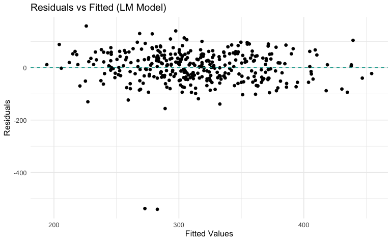

```r
# Load required library
library(ggplot2)

# Residual vs. Fitted plot for LM Model
ggplot(data = NULL, aes(x = lm_predictions, y = residuals_lm)) +
  geom_point() +
  geom_hline(yintercept = 0, linetype = "dashed", color = "#00A699") +
  labs(title = "Residuals vs Fitted (LM Model)", x = "Fitted Values", y = "Residuals") +
  theme_minimal()
```

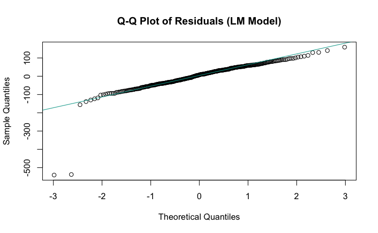

```r
# Q-Q Plot for LM Model residuals
qqnorm(residuals_lm, main = "Q-Q Plot of Residuals (LM Model)")
qqline(residuals_lm, col = "#00A699")
```

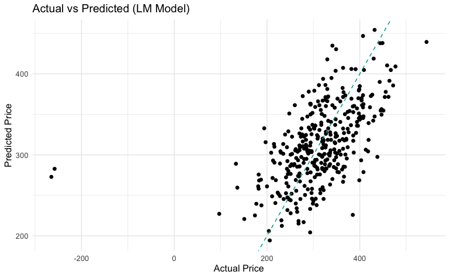

```r
# Actual vs Predicted for LM Model
ggplot(data = NULL, aes(x = test$price, y = lm_predictions)) +
  geom_point() +
  geom_abline(intercept = 0, slope = 1, linetype = "dashed", color = "#00A699") +
  labs(title = "Actual vs Predicted (LM Model)", x = "Actual Price", y = "Predicted Price") +
  theme_minimal()
```